# FMR1 Knockout

RNA-Seq Analysis

Melanie Hand & Steve Pederson

19/07/2019

## Setup

```r
library(limma)
library(edgeR)
library(AnnotationHub)
library(tidyverse)
library(magrittr)
library(pander)
library(RColorBrewer)
library(ggrepel)
library(scales)
library(here)
theme_set(theme_bw())
panderOptions("big.mark", ",")
panderOptions("table.split.table", Inf)
panderOptions("table.style", "rmarkdown")
if (interactive()) setwd(file.path(here(), "R"))
```

Annotation was set up as a EnsDb object based on Ensembl Release 94

```r
ah <- AnnotationHub() %>%
  subset(species == "Danio rerio") %>%
  subset(dataprovider == "Ensembl") %>%
  subset(rdataclass == "EnsDb")
ensDb <- AnnotationHub()[["AH64906"]]
genes <- genes(ensDb)
```

Prior to count-level analysis, the initial dataset was pre-processed using the following steps:

- Adapters were removed from any reads derived from RNA fragments < 300bp
- Bases were removed from the end of reads when the quality score dipped below 20
- Reads < 35bp after trimming were discarded

After trimming alignment was performed using STAR v2.5.3a to the *Danio rerio* genome included in Ensembl Release 94 (GRCz11). Aligned reads were counted for each gene if the following criteria were satisfied:

- Alignments were unique
- Alignments strictly overlapped exonic regions

```r
x <- file.path("../2_alignedData/featureCounts/genes.out") %>%
    read_tsv() %>%
    as.data.frame() %>%
    column_to_rownames("Geneid") %>%
    set_colnames(basename(colnames(.))) %>%
    set_colnames(str_remove(colnames(.), "_Aligned.+")) %>%
    magrittr::extract(rowSums(cpm(.) > 1) >= 4,) %>%
    DGEList(
        samples = tibble(
            sample = colnames(.),
            group = case_when(
                    sample %in% paste0("S", 1:8) ~ "FMR1",
                    !sample %in% paste0("S", 1:8)  ~ "Wildtype"
                  )) %>%
            mutate(group = factor(group, levels = c("Wildtype", "FMR1"))) %>%
            as.data.frame(),
        genes = genes[rownames(.)] %>%
            as.data.frame() %>%
            dplyr::select(
                ensembl_gene_id = gene_id,
                chromosome_name = seqnames,
                description,
                external_gene_name = gene_name
            )
    ) %>%
    calcNormFactors(method = "TMM") %>%
    estimateDisp()
```

```
## Design matrix not provided. Switch to the classic mode.
```

## Data Inspection

Data was subsequently configured for analysis using voom, in which the assumption of normality can be applied and sample weights can be incorporated. Sample weights were calculated assuming all samples belong to the same treatment group to ensure conservative weights are assigned.

```r
v <- x %>%
    voomWithQualityWeights(design = matrix(1, nrow = ncol(.)))
```

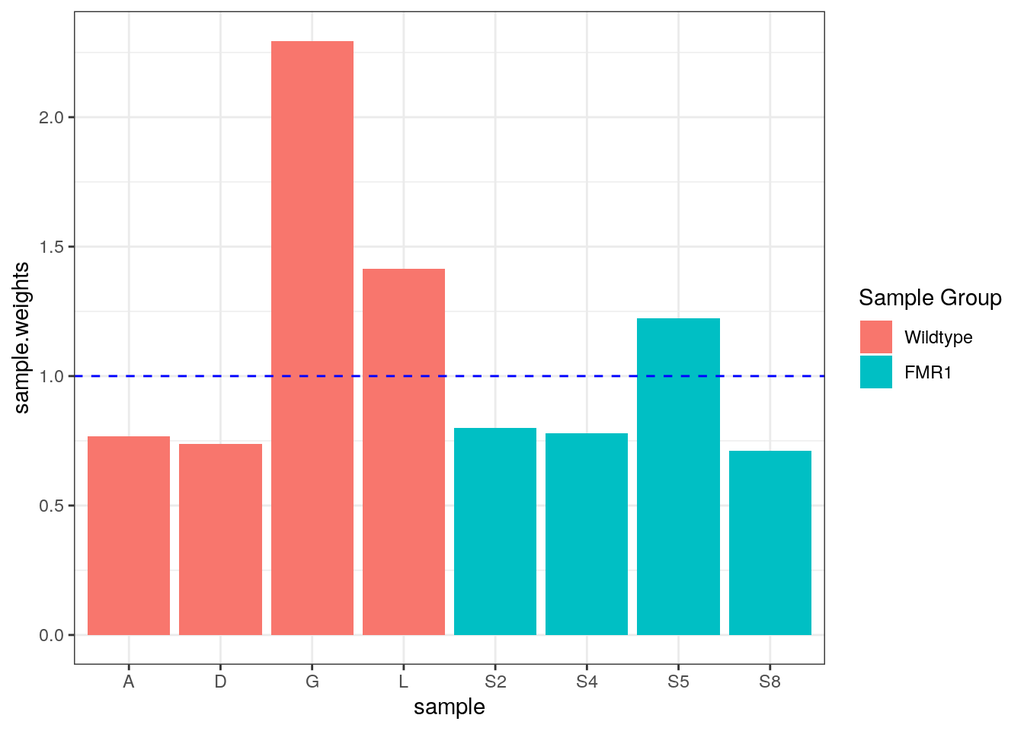

Sample weights with the ideal equal weight of 1 shown as a horizontal line.

```r
pca <- v$E %>%
    t() %>%
    prcomp()
```

A PCA was performed using logCPM transformed counts after removal of undetectable genes. Whilst some separation was observed, the location of sample S5 appeared less than satisfactory, and the spread between Wildtype samples also appeared to coincide with the largest source of variability in the data.

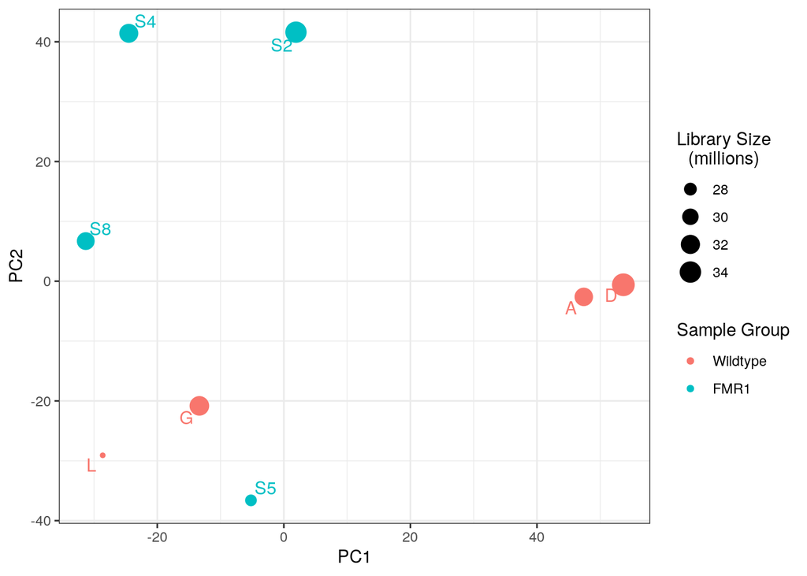

PCA of all samples. Point sizes indicate library sizes with the combination of PC1 & PC2 appearing to capture a considerable amount of this variation.

Finally, genotypes were checked using *fmr1* expression as a proxy. Expression of *fmr1* appeared to track with genotype as expected and no sample mislabelling was identified.

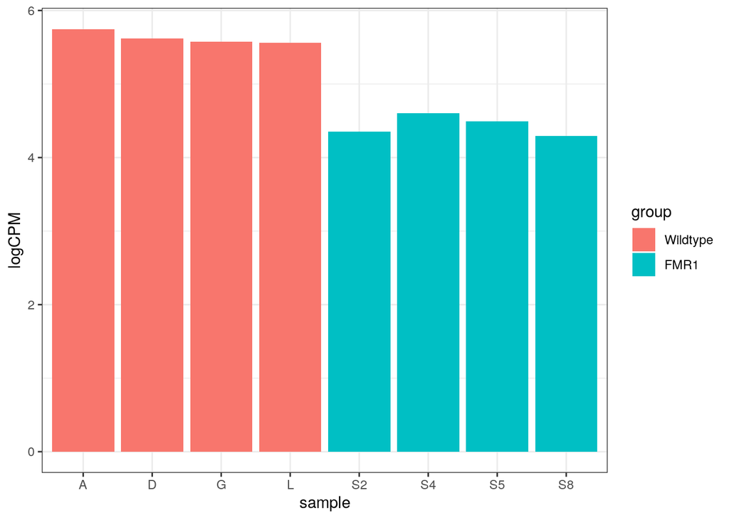

Expression of *fmr1* across all samples.

## Analysis

### DGE Analysis

The `voom` methodology was applied for differential gene expression (DGE) analysis, incorporating sample weights as calculated earlier. A simple two group design matrix was used.

```r
design <- model.matrix(~v$targets$group)
colnames(design) <- c("Wildtype", "FMR1vsWildtype")
efit <- v %>%
    lmFit(design) %>%
    eBayes()
```

```r
deGenes <- efit %>%
    topTable(coef = "FMR1vsWildtype", number = Inf, sort.by = "p") %>%
    as_tibble()
```

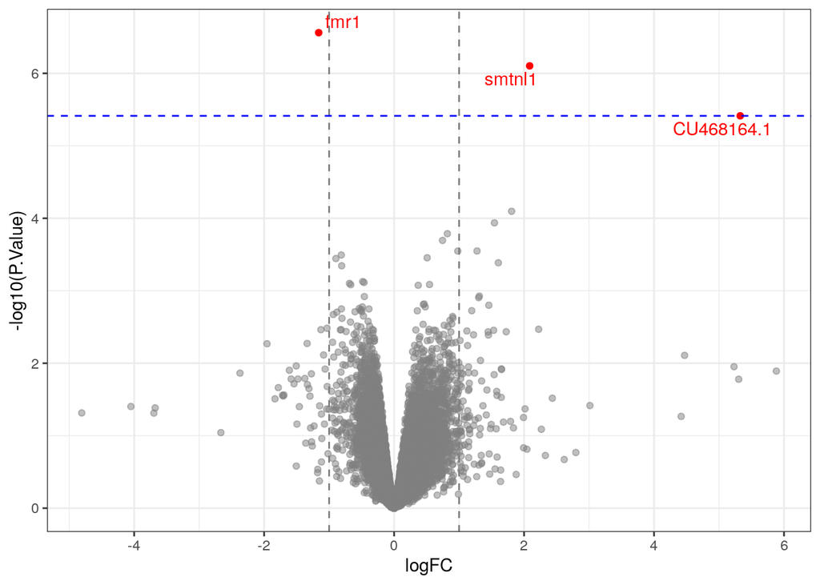

Volcano plot highlighting DE genes

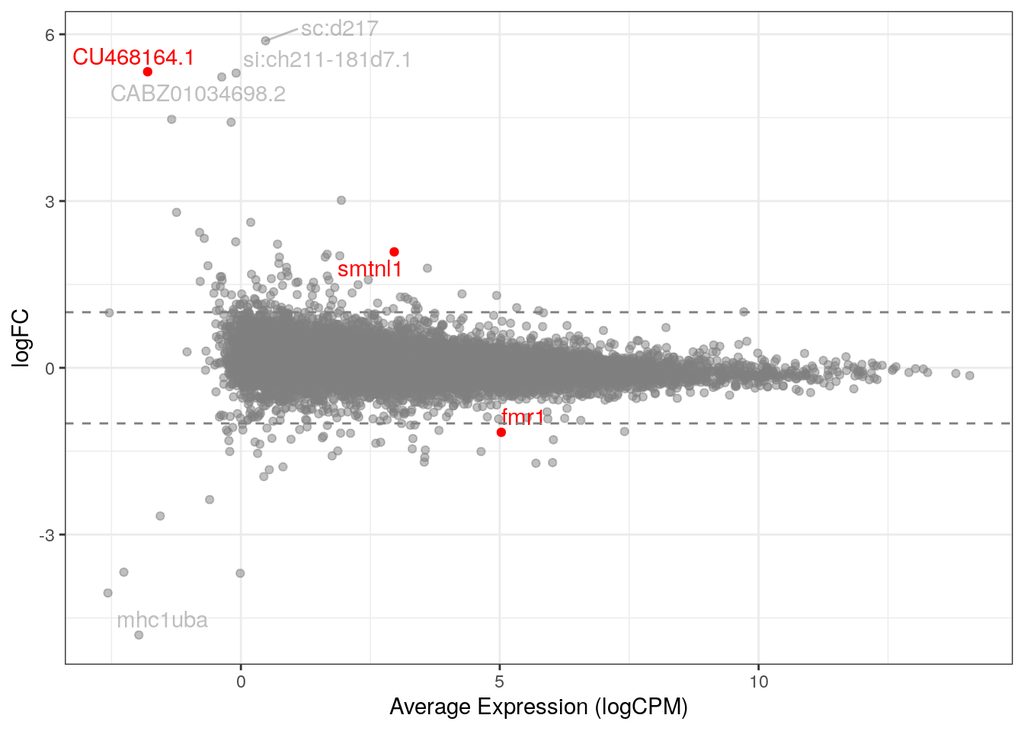

logFC plotted against expression level with significant DE genes shown in red.

The 3 genes considered as DE using an FDR of 0.05 were then inspected to confirm that the counts support their inclusion as DE.

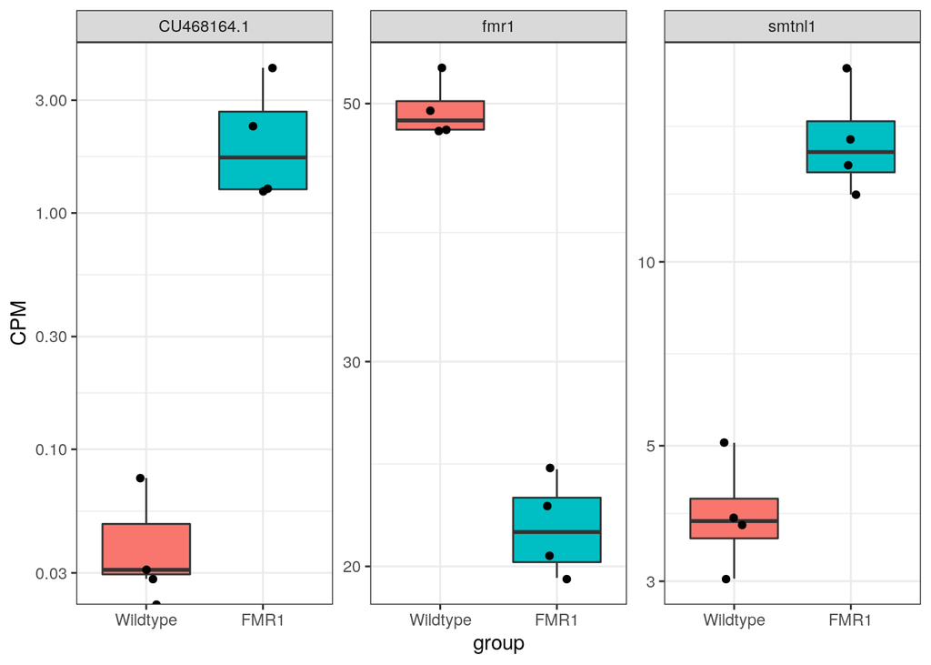

Expression values for eachof the DE genes using raw CPM values and a log-scale y-axis.

Top 10 results from DGE analysis. Adjusted p-values represent the Benjamini-Hochberg FDR.

| ensembl_gene_id | description | external_gene_name | logFC | AveExpr | t | P.Value | adj.P.Val |
| --- | --- | --- | --- | --- | --- | --- | --- |
| ENSDARG00000037433 | fragile X mental retardation 1 | fmr1 | -1.16 | 5.029 | -12.15 | 2.748e-07 | 0.005023 |
| ENSDARG00000041257 | smoothelin-like 1 | smtnl1 | 2.086 | 2.962 | 10.84 | 7.89e-07 | 0.007211 |
| ENSDARG00000052609 | uncharacterized LOC100005318 | CU468164.1 | 5.326 | -1.801 | 9.11 | 3.859e-06 | 0.02351 |
| ENSDARG00000104007 | protocadherin 1 gamma 1 | pcdh1g1 | 1.809 | 0.8814 | 6.402 | 8.007e-05 | 0.3659 |
| ENSDARG00000061585 | cytochrome P450, family 4, subfamily V, polypeptide 7 | cyp4v7 | 1.544 | 1.103 | 6.118 | 0.0001156 | 0.4228 |
| ENSDARG00000090993 | ring finger protein 4 | rnf4 | 0.8196 | 3.616 | 5.858 | 0.0001633 | 0.4975 |
| ENSDARG00000104491 | adenosine monophosphate deaminase 2a | ampd2a | 0.7452 | 2.666 | 5.702 | 0.0002021 | 0.5277 |
| ENSDARG00000102435 | pleckstrin homology domain containing, family F (with FYVE domain) member 1 | plekhf1 | 1.275 | 3.081 | 5.46 | 0.0002823 | 0.5479 |
| ENSDARG00000037097 | solute carrier family 7 (cationic amino acid transporter, y+ system), member 2 | slc7a2 | 0.9804 | 3.746 | 5.458 | 0.0002832 | 0.5479 |
| ENSDARG00000004472 | alpha tubulin acetyltransferase 1 | atat1 | -0.8126 | 4.018 | -5.369 | 0.0003208 | 0.5479 |

The final results were exported as the file `FMR1vWildtype.csv`

```r
write_csv(deGenes, "../results/FMR1vWildtype.csv")
```

### BLAST Analysis (FMR1)

For each of the 3 DE genes, a brief analysis was performed using the Ensembl BLAST server to search all cDNAs within the zebrafish transcriptome, with parameters set for distant homology. For each gene the longest transcript was chosen as the query sequence. Only results with an E-value < 1 were retained.

Summary of BLAST matches for *fmr1*

| Gene hit | description | Total Matches | Longest Match |
| --- | --- | --- | --- |
| fxr1 | fragile X mental retardation, autosomal homolog 1 | 4 | 1,359 |
| fxr2 | fragile X mental retardation, autosomal homolog 2 | 8 | 977 |
| anks1b | ankyrin repeat and sterile alpha motif domain containing 1B | 1 | 88 |
| pimr138 | Pim proto-oncogene, serine/threonine kinase, related 138 | 1 | 87 |
| si:dkey-90l23.1 | si:dkey-90l23.1 | 1 | 84 |
| eno3 | enolase 3, (beta, muscle) | 1 | 80 |
| nr2f6a | nuclear receptor subfamily 2, group F, member 6a | 1 | 75 |
| ZBTB26 | zinc finger and BTB domain containing 26 | 1 | 72 |
| nat10 | N-acetyltransferase 10 | 1 | 46 |
| rybpa | RING1 and YY1 binding protein a | 1 | 43 |
| ikzf5 | IKAROS family zinc finger 5 | 4 | 38 |
| ctdnep1b | CTD nuclear envelope phosphatase 1b | 1 | 38 |
| gnb1b | guanine nucleotide binding protein (G protein), beta polypeptide 1b | 1 | 35 |
| acvr2aa | activin A receptor type 2Aa | 2 | 34 |
| ube2d2 | ubiquitin-conjugating enzyme E2D 2 (UBC4/5 homolog, yeast) | 2 | 31 |
| traf3ip2l | TRAF3 interacting protein 2-like | 1 | 31 |

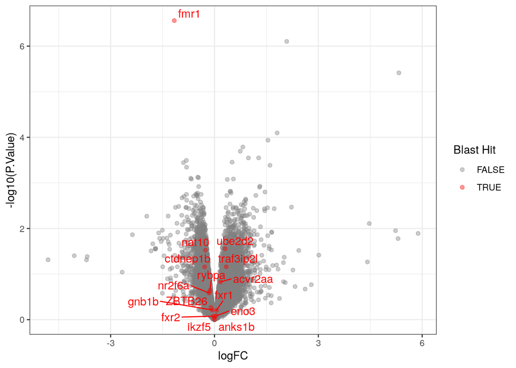

Volcano plot showing closest genes from the BLAST search on *fmr1*

### BLAST Analysis (Other genes)

Although not the subject of investigation, the genes detected as DE were analysed using BLAST as a reverse viewpoint on the experiment. Neither gene contained matches to *fmr1*.

Summary of BLAST matches for *smtnl1*

| Gene hit | description | Total Matches | Longest Match |
| --- | --- | --- | --- |
| smtna | smoothelin a | 1 | 297 |
| smtnb | smoothelin b | 4 | 258 |
| si:ch211-195o20.7 | si:ch211-195o20.7 | 1 | 173 |
| CU929178.1 | NUL | 1 | 134 |
| nefla | neurofilament, light polypeptide a | 3 | 132 |
| psd2 | pleckstrin and Sec7 domain containing 2 | 1 | 92 |
| si:dkey-20i20.10 | si:dkey-20i20.10 | 1 | 88 |
| taf3 | TAF3 RNA polymerase II, TATA box binding protein (TBP)-associated facto | 2 | 84 |
| tgfbr2a | transforming growth factor beta receptor 2a | 1 | 78 |
| ppp1r37 | protein phosphatase 1, regulatory subunit 37 | 1 | 76 |
| brd3b | bromodomain containing 3b | 3 | 63 |
| cmya5 | cardiomyopathy associated 5 | 2 | 61 |
| chd5 | chromodomain helicase DNA binding protein 5 | 1 | 60 |
| chd2 | chromodomain helicase DNA binding protein 2 | 2 | 58 |
| zgc:175284 | zgc:175284 | 2 | 54 |
| zgc:173726 | zgc:173726 | 6 | 52 |
| map6a | microtubule-associated protein 6a | 2 | 52 |
| si:dkey-20i20.9 | si:dkey-20i20.9 | 1 | 52 |
| znf1170 | zinc finger protein 1170 | 1 | 52 |
| stab2 | stabilin 2 | 4 | 51 |
| znf1166 | zinc finger protein 1166 | 3 | 51 |
| igfn1.1 | immunoglobulin-like and fibronectin type III domain containing 1, tandem duplicate 1 | 1 | 49 |
| zswim8 | zinc finger, SWIM-type containing 8 | 4 | 47 |
| kcnma1a | potassium large conductance calcium-activated channel, subfamily M, alpha member 1a | 3 | 44 |
| gpbp1l1 | GC-rich promoter binding protein 1-like 1 | 2 | 44 |
| foxn2b | forkhead box N2b | 1 | 43 |
| polr2f | polymerase (RNA) II (DNA directed) polypeptide F | 1 | 42 |
| lmod1a | leiomodin 1a (smooth muscle) | 1 | 41 |
| nktr | natural killer cell triggering receptor | 1 | 41 |
| im:7152348 | im:7152348 | 1 | 39 |
| jak2b | Janus kinase 2b | 1 | 35 |
| nop58 | NOP58 ribonucleoprotein homolog (yeast) | 1 | 35 |
| zfr2 | zinc finger RNA binding protein 2 | 2 | 29 |
| chd3 | chromodomain helicase DNA binding protein 3 | 3 | 23 |

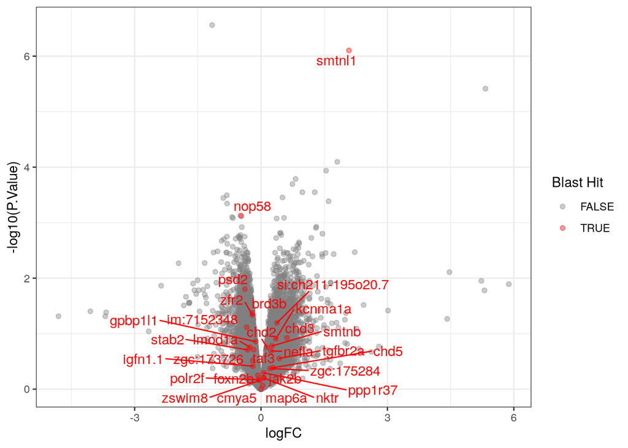

Volcano plot showing closest genes from the BLAST search on *smtnl1*

Summary of BLAST matches for *CU468164.1*

| Gene hit | description | Total Matches | Longest Match |
| --- | --- | --- | --- |
| si:ch211-262h13.3 | si:ch211-262h13.3 | 5 | 268 |
| si:ch211-244k5.1 | si:ch211-244k5.1 | 1 | 267 |
| si:dkey-242h9.3 | si:dkey-242h9.3 | 1 | 70 |
| or117-1 | odorant receptor, family F, subfamily 117, member 1 | 1 | 53 |
| cib1 | calcium and integrin binding 1 (calmyrin) | 2 | 39 |
| im:7147486 | im:7147486 | 2 | 35 |
| ppp1r18 | protein phosphatase 1, regulatory subunit 18 | 1 | 35 |

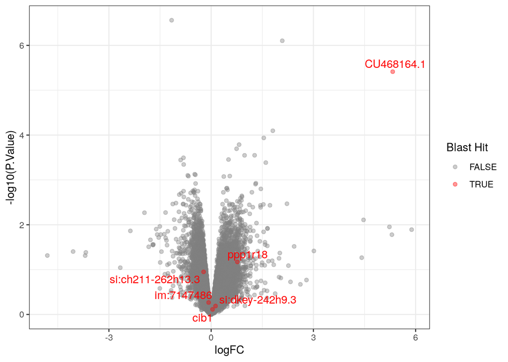

## Conclusion

# Session Info

**R version 3.6.3 (2020-02-29)**

**Platform:** x86_64-pc-linux-gnu (64-bit)

**locale:** *LC_CTYPE=en_AU.UTF-8*, *LC_NUMERIC=C*, *LC_TIME=en_AU.UTF-8*, *LC_COLLATE=en_AU.UTF-8*, *LC_MONETARY=en_AU.UTF-8*, *LC_MESSAGES=en_AU.UTF-8*, *LC_PAPER=en_AU.UTF-8*, *LC_NAME=C*, *LC_ADDRESS=C*, *LC_TELEPHONE=C*, *LC_MEASUREMENT=en_AU.UTF-8* and *LC_IDENTIFICATION=C*

**attached base packages:** *stats4*, *parallel*, *stats*, *graphics*, *grDevices*, *utils*, *datasets*, *methods* and *base*

**other attached packages:** *GenomicRanges(v.1.38.0)*, *GenomeInfoDb(v.1.22.1)*, *IRanges(v.2.20.2)*, *S4Vectors(v.0.24.4)*, *here(v.0.1)*, *scales(v.1.1.1)*, *ggrepel(v.0.8.2)*, *RColorBrewer(v.1.1-2)*, *pander(v.0.6.3)*, *magrittr(v.1.5)*, *forcats(v.0.5.0)*, *stringr(v.1.4.0)*, *dplyr(v.0.8.5)*, *purrr(v.0.3.4)*, *readr(v.1.3.1)*, *tidyr(v.1.0.3)*, *tibble(v.3.0.1)*, *ggplot2(v.3.3.0)*, *tidyverse(v.1.3.0)*, *AnnotationHub(v.2.18.0)*, *BiocFileCache(v.1.10.2)*, *dbplyr(v.1.4.3)*, *BiocGenerics(v.0.32.0)*, *edgeR(v.3.28.1)* and *limma(v.3.42.2)*

**loaded via a namespace (and not attached):** *nlme(v.3.1-147)*, *bitops(v.1.0-6)*, *fs(v.1.4.1)*, *lubridate(v.1.7.8)*, *bit64(v.0.9-7)*, *httr(v.1.4.1)*, *rprojroot(v.1.3-2)*, *tools(v.3.6.3)*, *backports(v.1.1.7)*, *R6(v.2.4.1)*, *DBI(v.1.1.0)*, *colorspace(v.1.4-1)*, *withr(v.2.2.0)*, *tidyselect(v.1.1.0)*, *bit(v.1.1-15.2)*, *curl(v.4.3)*, *compiler(v.3.6.3)*, *cli(v.2.0.2)*, *rvest(v.0.3.5)*, *Biobase(v.2.46.0)*, *xml2(v.1.3.2)*, *labeling(v.0.3)*, *rappdirs(v.0.3.1)*, *digest(v.0.6.25)*, *rmarkdown(v.2.1)*, *XVector(v.0.26.0)*, *pkgconfig(v.2.0.3)*, *htmltools(v.0.4.0)*, *highr(v.0.8)*, *fastmap(v.1.0.1)*, *rlang(v.0.4.6)*, *readxl(v.1.3.1)*, *rstudioapi(v.0.11)*, *RSQLite(v.2.2.0)*, *shiny(v.1.4.0.2)*, *farver(v.2.0.3)*, *generics(v.0.0.2)*, *jsonlite(v.1.6.1)*, *RCurl(v.1.98-1.2)*, *GenomeInfoDbData(v.1.2.2)*, *Rcpp(v.1.0.4.6)*, *munsell(v.0.5.0)*, *fansi(v.0.4.1)*, *lifecycle(v.0.2.0)*, *stringi(v.1.4.6)*, *yaml(v.2.2.1)*, *zlibbioc(v.1.32.0)*, *grid(v.3.6.3)*, *blob(v.1.2.1)*, *promises(v.1.1.0)*, *crayon(v.1.3.4)*, *lattice(v.0.20-41)*, *splines(v.3.6.3)*, *haven(v.2.2.0)*, *hms(v.0.5.3)*, *locfit(v.1.5-9.4)*, *knitr(v.1.28)*, *pillar(v.1.4.4)*, *reprex(v.0.3.0)*, *glue(v.1.4.1)*, *BiocVersion(v.3.10.1)*, *evaluate(v.0.14)*, *BiocManager(v.1.30.10)*, *modelr(v.0.1.7)*, *vctrs(v.0.3.0)*, *httpuv(v.1.5.2)*, *cellranger(v.1.1.0)*, *gtable(v.0.3.0)*, *assertthat(v.0.2.1)*, *xfun(v.0.13)*, *mime(v.0.9)*, *xtable(v.1.8-4)*, *broom(v.0.5.6)*, *later(v.1.0.0)*, *AnnotationDbi(v.1.48.0)*, *memoise(v.1.1.0)*, *ellipsis(v.0.3.0)* and *interactiveDisplayBase(v.1.24.0)*